# FJUEL workshop Dynamic documents in R: Introduction to Quarto

Session 3: Data import/export and data visualization

### Session 3: Learning goals

- Learn the basics of importing data into R and exporting data
- Become more familiar with the `{dplyr}` and `{ggplot2}` package

### Data and R: Warnings

- Importing data into R can be frustrating
- Getting them into shape for analysis is often tedious

### Data preparation: General workflow

- Data entry/annotation usually in MS Excel
- Store Excel spreadsheet in subfolder `data/input_data`
- Load into R (document this step in code form)
- Prepare for analysis
- Save in **.tsv** format in subfolder `data/analysis_data`

**Reproducibility**

The **.tsv** format ensures that your data can be opened using other software (interoperability).

### Download data

- Create subfolders:
  - `data/input_data`
  - `data/analysis_data`
- Download data files from `https://osf.io/j43v9/`
  - `data_quantifiers.tsv`
  - `data_quantifiers_wide.xlsx`
- Save them in subfolder `data/input_data`

### Data preparation: Simple rules

- Lots of work can be avoided by following a few simple rules
- Rows and columns
  - Columns are variables
  - Rows are observations
  - Avoid blank rows and blank columns
  - The first row gives the name of the variables

Learn more about [data preparation in spreadsheets](https://the-turing-way.netlify.app/reproducible-research/rdm/rdm-spreadsheets.html)

### Data preparation: Naming conventions

- Avoid **blank spaces** and **special symbols** (underscore _ is OK)
- Do not begin variable names with numbers
- R is **case-sensitive** (“Yes” and “yes” are treated as different)
- Code **missing values** (empty cells) as **NA**

**Errors**

A lot can go wrong when reading data into R. Make sure you routinely include error checks into your workflow. Always carefully inspect the data at different stages of processing/analysis.

### Data import

- Different functions for different file formats
- Most typical formats
  - **.xlsx** `read_excel()` (package: `readxl`)
  - **.csv** `read.csv()` or `read.csv2()`
  - **.txt** `read.delim()`
  - **.tsv** `read_tsv()` (package: `tidyverse`)

### Helpful button: “Import dataset”

- Use the button “Import dataset”
- Problem: Point-and-click commands not reproducible
- Solution: Copy-and-paste the generated R code into your notebook
- Change name of data frame: `d`
- Change directory path: Use `here()` (explained shortly)

### Importing Excel spreadsheets

- Load packages `{readxl}` and `{here}`
- If they are not installed yet, do so first: `install.packages()`

```r
library(readxl)
library(here)
```

### Using `here()` to locate files

- `here("directory", "file_name")`
- Root (where path begins) = project directory
- Find root

```r
here()
```

```
[1] "C:/Users/ba4rh5/Work Folders/My Files/R projects/teaching/phd_workshop"
```

### Read in Excel file

- Function: `read_xlsx()`
- Use assignment operator (shortcut: Alt -)
- Should appear in workspace (Environment)

```r
d <- read_xlsx(
  here(
    "data/input_data",
    "data_quantifiers_wide.xlsx"))
```

### Inspect data frame

- Look at contents

```r
str(d)
```

- Inspect first few rows:

```r
head(d)
```

### Read in .tsv file

- Function: `read_tsv()` (part of the `tidyverse`)

```r
library(tidyverse)

d <- read_tsv(
  here(
    "data/input_data",
    "data_quantifiers.tsv"))
```

Learn more about reading in different kinds of data: Wickham & Grolemund 2023: [Chapter 11](https://r4ds.had.co.nz/data-import.html)

### Inspect data frame

```r
str(d)
```

```
spc_tbl_ [80 × 3] (S3: spec_tbl_df/tbl_df/tbl/data.frame)
 $ subject   : chr [1:80] "subj_01" "subj_02" "subj_03" "subj_04" ...
 $ quantifier: chr [1:80] "few" "few" "few" "few" ...
 $ percent   : num [1:80] 5 20 10 8 12 15 25 10 15 10 ...
 - attr(*, "spec")=
  .. cols(
  ..   subject = col_character(),
  ..   quantifier = col_character(),
  ..   percent = col_double()
  .. )
 - attr(*, "problems")=<externalptr>
```

### Look at the first rows of a data frame: `head()`

```r
head(d)
```

```
# A tibble: 6 × 3
  subject quantifier percent
  <chr>   <chr>        <dbl>
1 subj_01 few              5
2 subj_02 few             20
3 subj_03 few             10
4 subj_04 few              8
5 subj_05 few             12
6 subj_06 few             15
```

### Use `$` to access a column (variable) in the data frame

```r
d$percent
```

```
 [1]  5.0 20.0 10.0  8.0 12.0 15.0 25.0 10.0 15.0 10.0 10.0 10.0  7.0 15.0 15.0
[16]  6.0  5.0 10.0 15.0 10.0 15.0 35.0 27.5 20.0 30.0 35.0 40.0 30.0 33.0 33.0
[31] 25.0 40.0 20.0 40.0 30.0 14.0 12.5 25.0 40.0 20.0 30.0 70.0 65.0 51.0 50.0
[46] 60.0 67.5 60.0 67.0 67.0 50.0 70.0 60.0 69.0 75.0 75.0 65.0 70.0 75.0 80.0
[61] 50.0 80.0 85.0 80.0 75.0 90.0 92.5 80.0 85.0 90.0 75.0 90.0 85.0 90.0 85.0
[76] 91.0 80.0 90.0 90.0 90.0
```

### Write a data table to file: `write_tsv()`

```r
write_tsv(
  d,
  here(
    "data/analysis_data",
    "data_quantifiers.tsv"))
```

**Saving data tables**

To make sure you never overwrite the input data file, keep the input data in the subfolder `data/input_data`, and the processed data in the subfolder `data/analysis_data`.

### Working with data: The `dplyr` package

- Use the `dplyr` package (part of the `tidyverse`)
- General approach: **Piping**
  - Pipe operator `|>` or `%>%`
  - Keyboard shortcut: Ctrl Shift M
- Perform a sequence (pipeline) of operations on data frames

[figure not shown]

### `dplyr` functions

- `filter()` Select a subset of observations
- `select()` Select a subset of variables
- `arrange()` Change order of rows based on a variable
- `mutate()` Add new variables that are functions of data in the table
- `summarize()` Obtain data summaries (mean, count, sd, etc.)
- `group_by()` Form groups

Learn more: Wickham & Grolemund 2023: [Chapter 4](https://r4ds.had.co.nz/workflow-basics.html), [Chapter 5](https://r4ds.had.co.nz/transform.html) | **Vignettes** for the `dplyr` package

### Select a subset of observations: `filter()`

- Specify subset based on levels/values of a variable
- In R, “is equal to” is `==`

```r
d |> filter(subject == "subj_01")
```

```
# A tibble: 4 × 3
  subject quantifier percent
  <chr>   <chr>        <dbl>
1 subj_01 few              5
2 subj_01 some            15
3 subj_01 many            30
4 subj_01 most            50
```

### Select a subset of variables: `select()`

```r
d |> select(subject, percent)
```

```
# A tibble: 80 × 2
   subject percent
   <chr>     <dbl>
 1 subj_01       5
 2 subj_02      20
 3 subj_03      10
 4 subj_04       8
 5 subj_05      12
 6 subj_06      15
 7 subj_07      25
 8 subj_08      10
 9 subj_09      15
10 subj_10      10
# ℹ 70 more rows
```

### Reorder rows based on a variable: `arrange()`

```r
d |> arrange(quantifier)
```

```
# A tibble: 80 × 3
   subject quantifier percent
   <chr>   <chr>        <dbl>
 1 subj_01 few              5
 2 subj_02 few             20
 3 subj_03 few             10
 4 subj_04 few              8
 5 subj_05 few             12
 6 subj_06 few             15
 7 subj_07 few             25
 8 subj_08 few             10
 9 subj_09 few             15
10 subj_10 few             10
# ℹ 70 more rows
```

### Data summary: `group_by()` and `summarize()`

- Obtain data summaries (mean, count, sd, etc.)

```r
d |>
  group_by(subject) |>
  summarize(
    mean_percent = mean(percent))
```

```
# A tibble: 20 × 2
   subject mean_percent
   <chr>          <dbl>
 1 subj_01         25
 2 subj_02         51.2
 3 subj_03         46.9
 4 subj_04         39.8
 5 subj_05         41.8
 6 subj_06         50
 7 subj_07         56.2
 8 subj_08         45
 9 subj_09         50
10 subj_10         50
11 subj_11         40
12 subj_12         52.5
13 subj_13         43
14 subj_14         53.5
15 subj_15         51.2
16 subj_16         46.5
17 subj_17         40.6
18 subj_18         48.8
19 subj_19         55
20 subj_20         50
```

### `dplyr` functions: Longer pipes

- Mean percentage by subject: `group_by()` and `summarize()`

```r
d |>
  group_by(subject) |>
  summarize(
    mean_percent = mean(percent))
```

```
# A tibble: 20 × 2
   subject mean_percent
   <chr>          <dbl>
 1 subj_01         25
 2 subj_02         51.2
 3 subj_03         46.9
 4 subj_04         39.8
 5 subj_05         41.8
 6 subj_06         50
 7 subj_07         56.2
 8 subj_08         45
 9 subj_09         50
10 subj_10         50
11 subj_11         40
12 subj_12         52.5
13 subj_13         43
14 subj_14         53.5
15 subj_15         51.2
16 subj_16         46.5
17 subj_17         40.6
18 subj_18         48.8
19 subj_19         55
20 subj_20         50
```

### `dplyr` functions: Longer pipes

- Sort subjects by mean percentage: `arrange()`

```r
d |>
  group_by(subject) |>
  summarize(
    mean_percent = mean(percent)) |>
  arrange(mean_percent)
```

```
# A tibble: 20 × 2
   subject mean_percent
   <chr>          <dbl>
 1 subj_01         25
 2 subj_04         39.8
 3 subj_11         40
 4 subj_17         40.6
 5 subj_05         41.8
 6 subj_13         43
 7 subj_08         45
 8 subj_16         46.5
 9 subj_03         46.9
10 subj_18         48.8
11 subj_06         50
12 subj_09         50
13 subj_10         50
14 subj_20         50
15 subj_02         51.2
16 subj_15         51.2
17 subj_12         52.5
18 subj_14         53.5
19 subj_19         55
20 subj_07         56.2
```

### `dplyr` functions: Longer pipes

- We want to sort in descending order: `desc(...)`

```r
d |>
  group_by(subject) |>
  summarize(
    mean_percent = mean(percent)) |>
  arrange(desc(mean_percent))
```

```
# A tibble: 20 × 2
   subject mean_percent
   <chr>          <dbl>
 1 subj_07         56.2
 2 subj_19         55
 3 subj_14         53.5
 4 subj_12         52.5
 5 subj_02         51.2
 6 subj_15         51.2
 7 subj_06         50
 8 subj_09         50
 9 subj_10         50
10 subj_20         50
11 subj_18         48.8
12 subj_03         46.9
13 subj_16         46.5
14 subj_08         45
15 subj_13         43
16 subj_05         41.8
17 subj_17         40.6
18 subj_11         40
19 subj_04         39.8
20 subj_01         25
```

### `dplyr` functions: Longer pipes

```r
d |>
  group_by(subject) |>
  summarize(
    mean_percent = mean(percent)) |>
  arrange(desc(mean_percent)) |>
  filter(mean_percent <= 40)
```

```
# A tibble: 3 × 2
  subject mean_percent
  <chr>          <dbl>
1 subj_11         40
2 subj_04         39.8
3 subj_01         25
```

# Data visualization

### Data visualization: Resources

- Use the `ggplot2` package (part of the `tidyverse`)
- [Healy 2017](https://kieranhealy.org/publications/dataviz/)
- Wickham & Grolemund 2023: [Chapter 3](https://r4ds.had.co.nz/data-visualisation.html) (free online)
- [Chang 2023](https://r-graphics.org/) (free online)

[figure not shown]

**ggplot2**

The way in which `ggplot2` works may seem confusing at first. However, it is a very flexible and powerful tool and has become the de-facto standard for advanced data visualization in R. There is a large community of users, which makes it easy to find help online.

### Data visualization: Quantifier data

- Obtain distribution of percentage means across subjects

```r
d |>
  group_by(subject) |>
  summarize(
    mean_percent = mean(percent))
```

```
# A tibble: 20 × 2
   subject mean_percent
   <chr>          <dbl>
 1 subj_01         25
 2 subj_02         51.2
 3 subj_03         46.9
 4 subj_04         39.8
 5 subj_05         41.8
 6 subj_06         50
 7 subj_07         56.2
 8 subj_08         45
 9 subj_09         50
10 subj_10         50
11 subj_11         40
12 subj_12         52.5
13 subj_13         43
14 subj_14         53.5
15 subj_15         51.2
16 subj_16         46.5
17 subj_17         40.6
18 subj_18         48.8
19 subj_19         55
20 subj_20         50
```

- Visualize using a **dot diagram**

```r
d |>
  group_by(subject) |>
  summarize(
    mean_percent = mean(percent)) |>
  ggplot(aes(x = mean_percent)) +
  geom_dotplot(binwidth = 1)
```

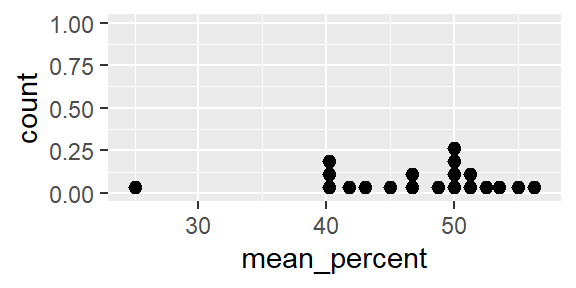

### Saving graphics using `ggsave()`

```r
ggsave(
  here(
    "figures",
    "mean_percentage_by_subject.pdf"),
  width = 3,
  height = 1.5)
```

**Saving graphs: File format**

Always save graphs as PDF files, to have publication-quality images. If you need to insert a graph into a PowerPoint (or Word), use the free software [IrfanView](https://www.chip.de/downloads/IrfanView-64-Bit_81722226.html): (1) Open the PDF using Adobe Acrobat, (2) Zoom in/out to set the resolution, (3) Make a screenshot, (4) Paste it (Ctrl. + V) into IrfanView, (5) cut out the graph (Ctrl. + C), and (6) paste it (Ctrl. + V) into PowerPoint/Word.

[figure not shown]

[figure not shown]

### ggplot2: Dot plot

```r
d |> group_by(subject) |>
  summarize(mean_percent = mean(percent)) |>
  ggplot(aes(x = mean_percent,
             y = subject)) +
  geom_point()
```

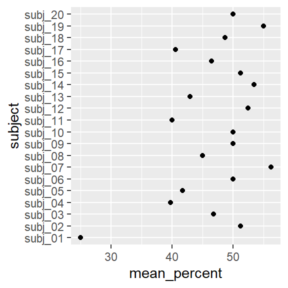

### ggplot2: Dot plot (ordered)

```r
d |> group_by(subject) |>
  summarize(mean_percent = mean(percent)) |>
  ggplot(aes(x = mean_percent,
             y = reorder(subject, mean_percent))) +
    geom_point()
```

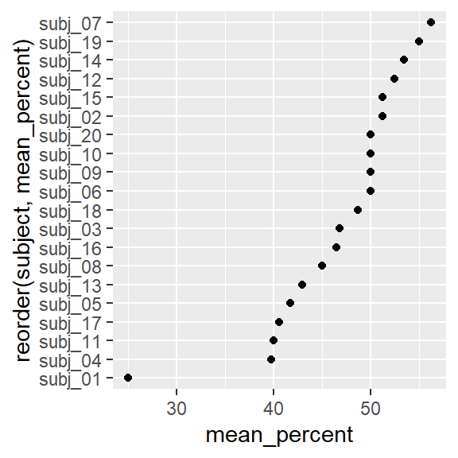

### ggplot2: Dot plot

- Change axis labels

```r
d |> group_by(subject) |>
  summarize(mean_percent = mean(percent)) |>
  ggplot(aes(x = mean_percent,
             y = reorder(subject, mean_percent))) +
  geom_point() +
  xlab("Mean percentage") +
  ylab(NULL)
```

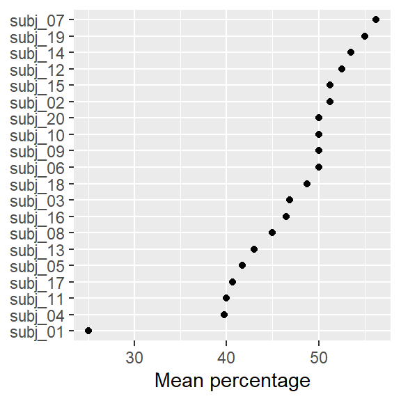

### ggplot2: Dot plot

- Change into bar chart

```r
d |> group_by(subject) |>
  summarize(mean_percent = mean(percent)) |>
  ggplot(aes(x = mean_percent,
             y = reorder(subject, mean_percent))) +
  geom_col() +
  xlab("Mean percentage") +
  ylab(NULL)
```

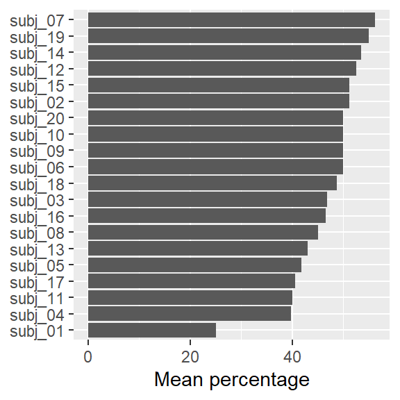

# Session 3: Practice

Time for practice! The tasks are available [here](https://lsoenning.github.io/resources_pages/practice_3.html). (there is also a link on my website)